# **Panorama da inflação**

Os principais índices de inflação do Brasil, apontam em junho de 2010 um avanço da inflação de em média **0.25%**. Com esse resultado, no ano a inflação acumula uma variação média positiva de **3.83%**, e em 12 meses uma variação média acumulada de **4.92%**.

|  | Variação mensal | Variação acumulada no ano | Variação acumulada em 12 meses |
| --- | --- | --- | --- |
| IPCA | 0% | 3.09% | 4.84% |
| INPC | -0.11% | 3.38% | 4.76% |
| IGP-M | 0.85% | 5.02% | 5.17% |
| IGP-DI | 0.34% | 4.43% | 5.07% |
| IPA | 0.43% | 0.06% | 0.05% |
| IPC | -0.21% | 2.31% | 4.93% |
| INCC | 1.09% | 4.95% | 6.48% |

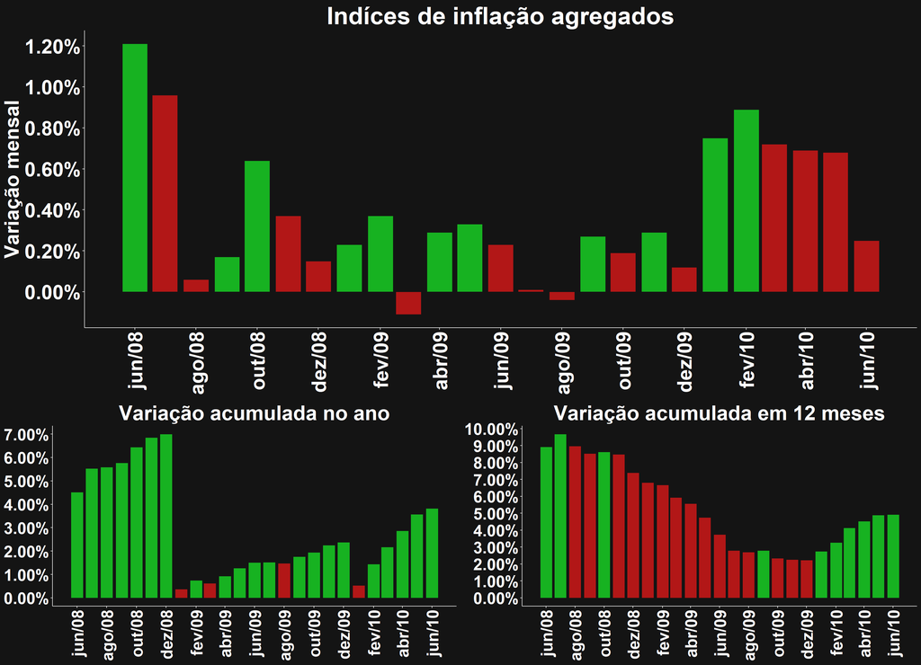

Índices selecionados para a média: IPCA, INPC e IGP-M.

# IPCA

O Indíce de Preços ao Consumidor Amplo (IPCA) variou 0% em junho, valor inferior ao mesmo período do ano anterior quando apresentou uma taxa de 0.36%. Com esse resultado o indíce acumula no ano uma variação positiva de 3.09%, e em 12 meses uma variação positiva de 4.84%.

|  | 06/2009 | 05/2010 | 06/2010 |
| --- | --- | --- | --- |
| Variação mensal | 0.36% | 0.43% | 0% |
| Variação acumulada no ano | 2.57% | 3.09% | 3.09% |
| Variação acumulada em 12 meses | 4.8% | 5.22% | 4.84% |

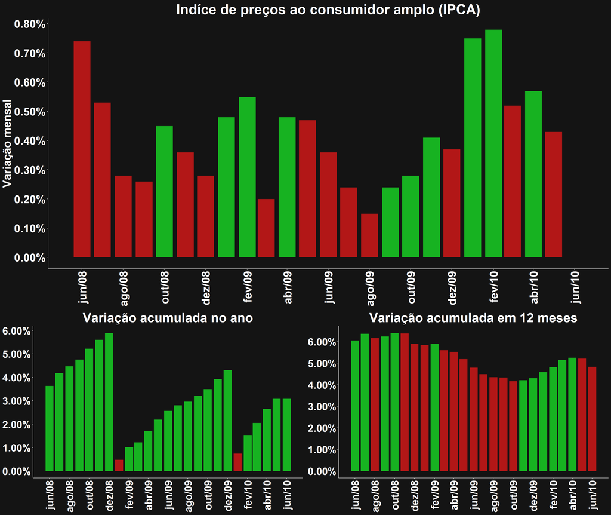

Os grupos que tiveram maior resultado positivo foram Despesas pessoais (0.74%) e Vestuário (0.58%), e negativo Alimentação e bebidas (-0.9%) e Transportes (-0.21%).

|  | Variação mensal | Variação acumulada no ano | Peso mensal |
| --- | --- | --- | --- |
| Alimentação e bebidas | -0.9% | 4.53% | 23.04% |
| Habitação | 0.4% | 2.18% | 13.16% |
| Artigos de residência | 0.35% | 2.7% | 4.16% |
| Vestuário | 0.58% | 3.25% | 6.72% |
| Transportes | -0.21% | 1.5% | 19.06% |
| Saúde e cuidados pessoais | 0.57% | 3.05% | 10.79% |
| Despesas pessoais | 0.74% | 4.17% | 10.24% |
| Educação | 0.03% | 5.56% | 7.23% |
| Comunicação | 0.02% | 0.09% | 5.59% |

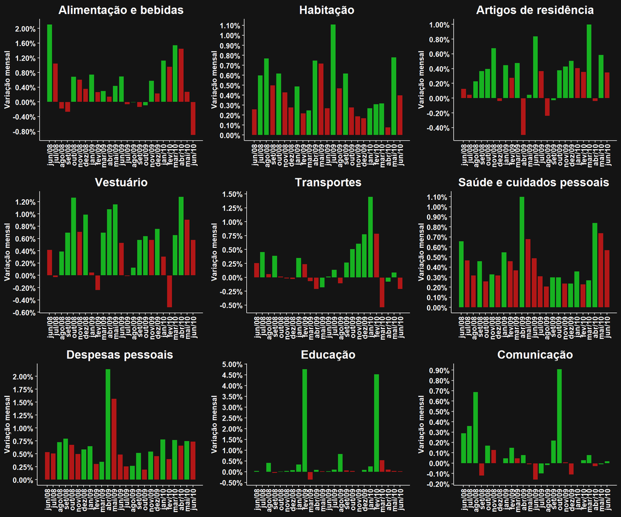

A nível de sub-itens os que mais influenciaram positivamente no resultado em relação ao seu peso foram Cigarro (3.7%%) e Passagem aérea (12.57%%), e negativamente Batata-inglesa (-23.97%%) e Leite pasteurizado (-3.78%%).

|  | Variação mensal | Variação acumulada no ano | Peso mensal |
| --- | --- | --- | --- |
| Cigarro | 3.7% | 3.7% | 1.02% |
| Passagem aérea | 12.57% | -11.09% | 0.29% |
| Refeição | 0.8% | 4.33% | 4.34% |
| Aluguel residencial | 0.74% | 3.14% | 2.77% |

|  | Variação mensal | Variação acumulada no ano | Peso mensal |
| --- | --- | --- | --- |
| Gasolina | -0.76% | -0.99% | 3.98% |
| Batata-inglesa | -23.97% | 19.44% | 0.37% |
| Leite pasteurizado | -3.78% | 18.95% | 1.12% |
| Açúcar refinado | -9.78% | 10.11% | 0.36% |

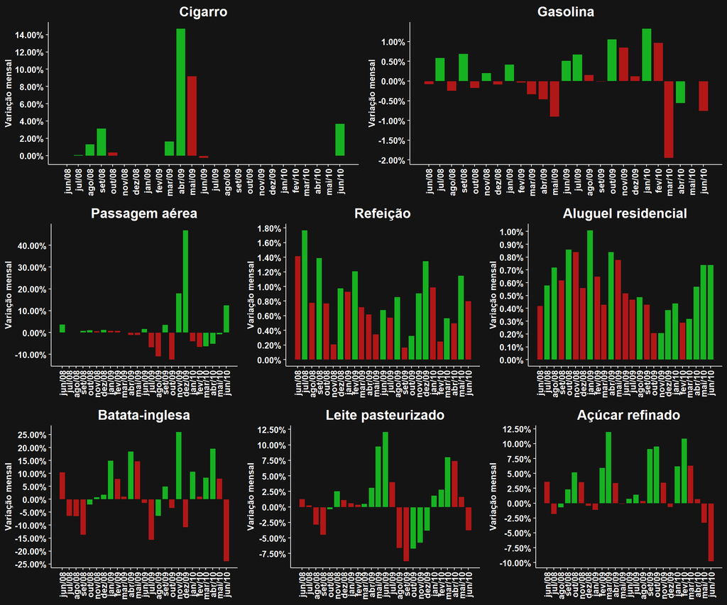

# INPC

O Indíce Nacional de Preços ao Consumidor (INPC) variou -0.11% em junho, valor inferior ao mesmo período do ano anterior quando apresentou uma taxa de 0.42%. Com esse resultado o indíce acumula no ano uma variação positiva de 3.38%, e em 12 meses uma variação positiva de 4.76%.

|  | 06/2009 | 05/2010 | 06/2010 |
| --- | --- | --- | --- |
| Variação mensal | 0.42% | 0.43% | -0.11% |
| Variação acumulada no ano | 2.75% | 3.5% | 3.38% |
| Variação acumulada em 12 meses | 4.94% | 5.31% | 4.76% |

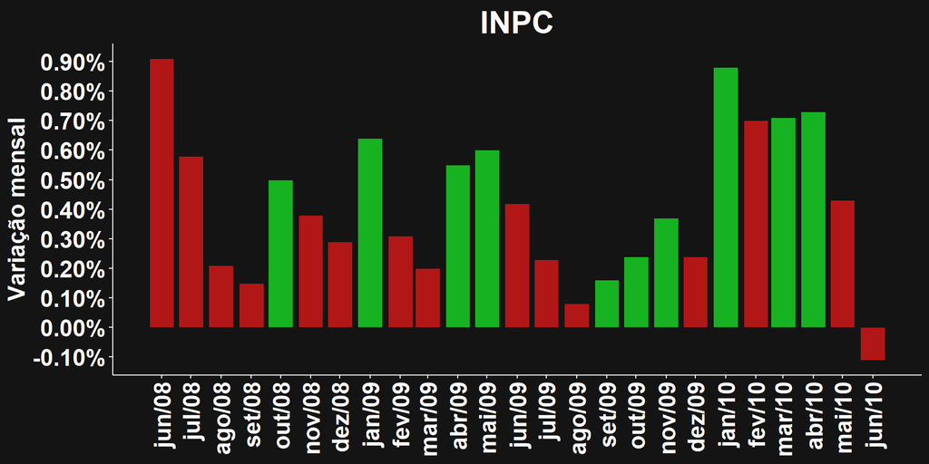

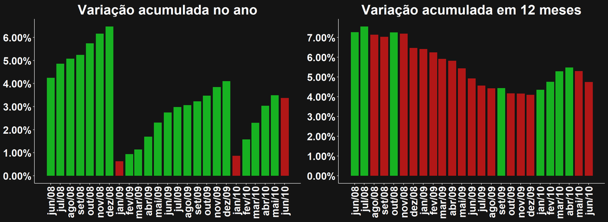

# IGP-M

O Indíce Geral de Preços de Mercado (IGP-M) variou 0.85% em junho, valor superior ao mesmo período do ano anterior quando apresentou uma taxa de -0.1%. Com esse resultado o indíce acumula no ano uma variação positiva de 5.02%, e em 12 meses uma variação positiva de 5.17%.

|  | 06/2009 | 05/2010 | 06/2010 |
| --- | --- | --- | --- |
| Variação mensal | -0.1% | 1.19% | 0.85% |
| Variação acumulada no ano | -0.8% | 4.14% | 5.02% |
| Variação acumulada em 12 meses | 1.52% | 4.18% | 5.17% |

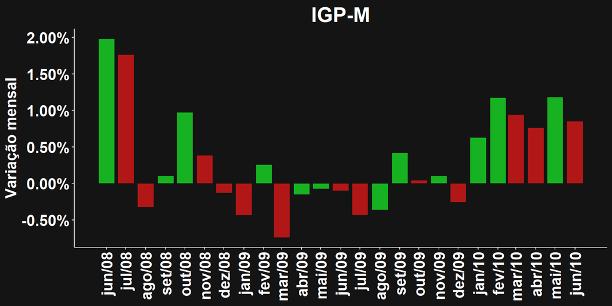

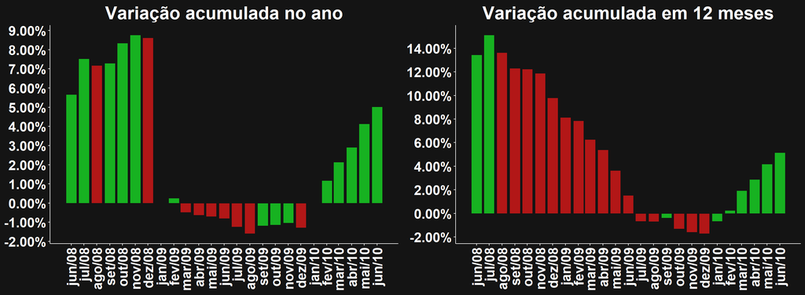

# IGP-DI

O Indíce Geral de Preços - Disponibilidade Interna (IGP-DI) variou 0.34% em junho, valor superior ao mesmo período do ano anterior quando apresentou uma taxa de -0.32%. Com esse resultado o indíce acumula no ano uma variação positiva de 4.43%, e em 12 meses uma variação positiva de 5.07%.

|  | 06/2009 | 05/2010 | 06/2010 |
| --- | --- | --- | --- |
| Variação mensal | -0.32% | 1.57% | 0.34% |
| Variação acumulada no ano | -1.06% | 4.07% | 4.43% |
| Variação acumulada em 12 meses | 0.76% | 4.38% | 5.07% |

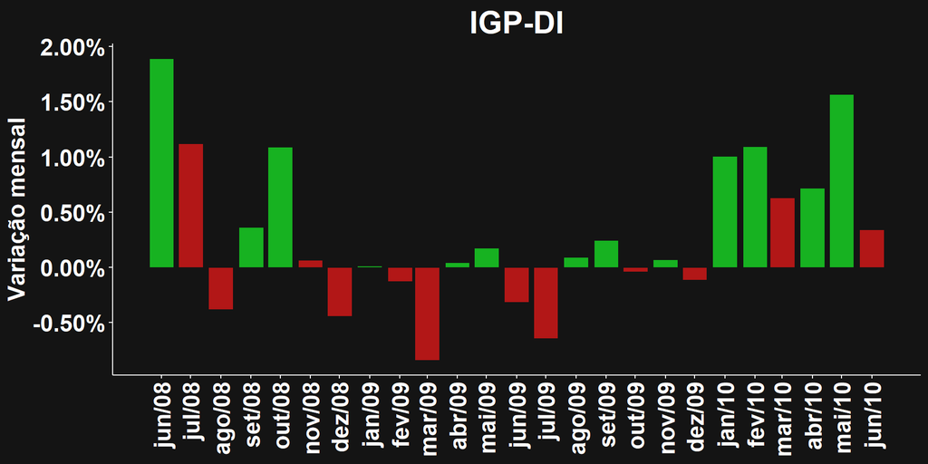

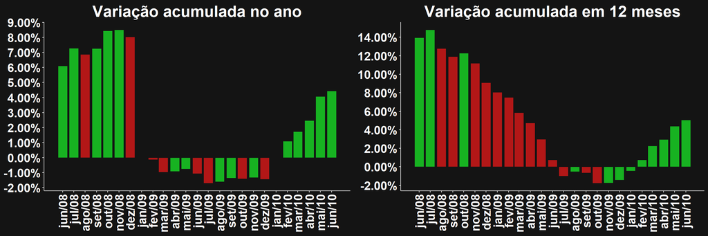

|  | 06/2009 | 05/2010 | 06/2010 |
| --- | --- | --- | --- |
| Variação mensal | -0.64% | 2.06% | 0.43% |
| Variação acumulada no ano | -0.03% | 0.06% | 0.06% |
| Variação acumulada em 12 meses | -0.02% | 0.04% | 0.05% |

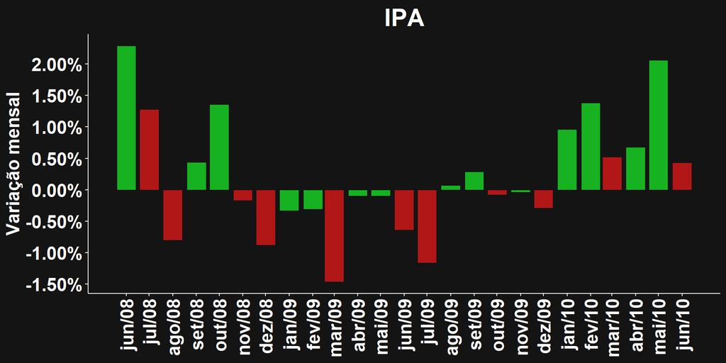

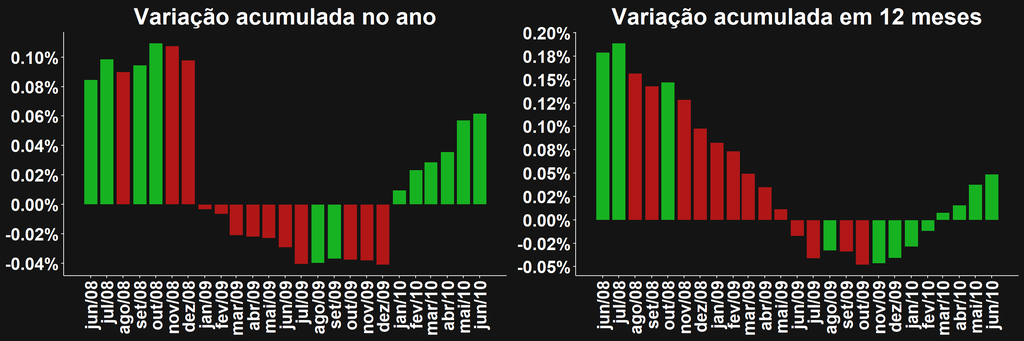

O Indíce de Preços ao Consumidor (IPC), integrante do IGP-DI com peso de 30%, apresentou variação de -0.21% em junho, valor inferior ao mesmo período do ano anterior quando apresentou uma taxa de 0.12%. Com esse resultado o indíce acumula no ano uma variação positiva de 2.31%, e em 12 meses uma variação positiva de 4.93%.

|  | 06/2009 | 05/2010 | 06/2010 |
| --- | --- | --- | --- |
| Variação mensal | 0.12% | 0.21% | -0.21% |
| Variação acumulada no ano | 1.82% | 2.53% | 2.31% |
| Variação acumulada em 12 meses | 4.87% | 5.28% | 4.93% |

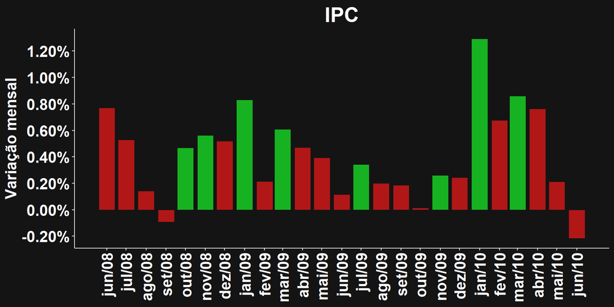

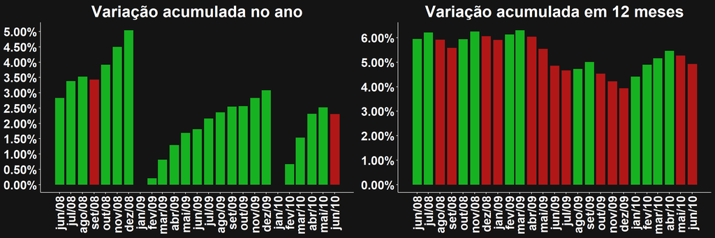

O Indíce Nacional de Custos de Construção (INCC), integrante do IGP-DI com peso de 10%, apresentou variação de 1.09% em junho, valor superior ao mesmo período do ano anterior quando apresentou uma taxa de 0.7%. Com esse resultado o indíce acumula no ano uma variação positiva de 4.95%, e em 12 meses uma variação positiva de 6.48%.

|  | 06/2009 | 05/2010 | 06/2010 |
| --- | --- | --- | --- |
| Variação mensal | 0.7% | 1.81% | 1.09% |
| Variação acumulada no ano | 2.08% | 3.82% | 4.95% |
| Variação acumulada em 12 meses | 7.67% | 6.07% | 6.48% |

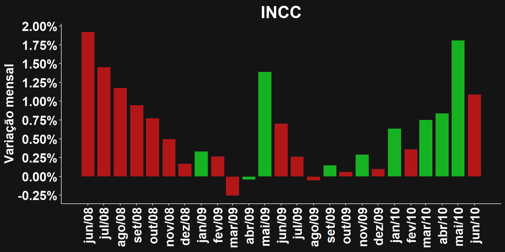

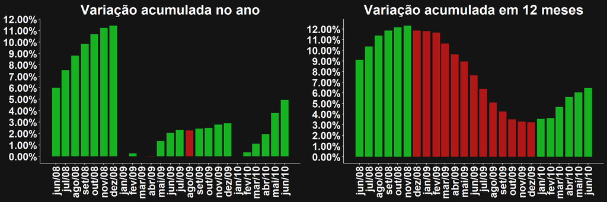

# Estatísticas

As estatísticas descritivas a seguir são feitas com base nos últimos 48 meses, e tem como objetivo possibilitar a avaliação do resultado observado em comparação aos períodos anteriores.

|  | Minimo | 1 Quartil | Mediana | Media | 3 Quartil | Maximo | Desvio Padrão |
| --- | --- | --- | --- | --- | --- | --- | --- |
| IPCA | 0% | 0.28% | 0.38% | 0.4% | 0.48% | 0.79% | 0.18% |
| INPC | -0.11% | 0.25% | 0.42% | 0.43% | 0.59% | 0.97% | 0.25% |
| IGP-M | -0.74% | 0.04% | 0.38% | 0.48% | 0.87% | 1.98% | 0.62% |
| IGP-DI | -0.84% | 0.09% | 0.35% | 0.47% | 0.99% | 1.89% | 0.62% |
| IPA | -1.46% | -0.05% | 0.37% | 0.49% | 1.1% | 2.29% | 0.87% |
| IPC | -0.21% | 0.2% | 0.34% | 0.4% | 0.61% | 1.29% | 0.3% |
| INCC | -0.26% | 0.25% | 0.43% | 0.58% | 0.79% | 2.02% | 0.51% |

Levando em consideração o desvio padrão de cada indíce, proporcionalmente os que mais se afastaram da média foram o IPCA, o INPC e o IPC.

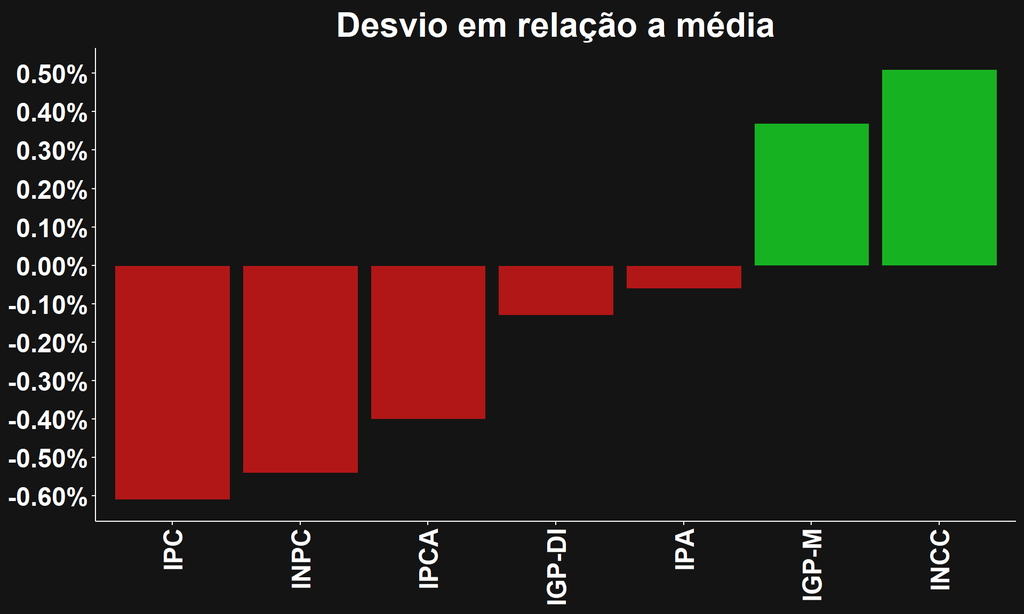

**João Victor Gomes**  
**jvg.santana@gmail.com**  
**[linkedin.com/in/jvictorgomes](https://www.linkedin.com/in/jvictorgomes/)**